# Manufacturing-Line Productivity Analysis

## 28/12/24

This is a manufacturing-Line Productivity Analysis for a bottling company. Some of the steps i've taken to clean the data include;

- first i imported my libraries.
- i imported the dataset.
- i made sure there were no null(empty) values.
- i made sure there were no duplicates.
- i calculated the processing time.

After cleaning and optimizing the dataset for interpreation.

- i started my analysis, identifying key insights, like; group analyis, daily productivity, etc.
- lastly i created the visualizations for my insights, adding more insights as i progressed.

The company has 4 operators, and their products with their flavours include:

- Orange 600ml (OR-600)
- Lemon Lime 600ml (LE-600)
- Cola 600ml (CO-600)
- Diet Cola 600ml (DC-600)
- Root Beer 600ml (RB-600)
- Cola 2L (CO-2L)

```python
import pandas as pd
import matplotlib.pyplot as plt
import seaborn as sns
import openpyxl
import numpy as np
```

```python
df = pd.read_excel(r'C:\Users\Isaac\Documents\Data Analysis\Manufacturing Line\Manufacturing_Line_Productivity.xlsx')
```

```python
df
```

|  | Date | Product | Batch | Operator | Start Time | End Time |
| --- | --- | --- | --- | --- | --- | --- |
| 0 | 2024-08-29 | OR-600 | 422111 | Mac | 11:50:00 | 14:05:00 |
| 1 | 2024-08-29 | LE-600 | 422112 | Mac | 14:05:00 | 15:45:00 |
| 2 | 2024-08-29 | LE-600 | 422113 | Mac | 15:45:00 | 17:35:00 |
| 3 | 2024-08-29 | LE-600 | 422114 | Mac | 17:35:00 | 19:15:00 |
| 4 | 2024-08-29 | LE-600 | 422115 | Charlie | 19:15:00 | 20:39:00 |
| 5 | 2024-08-29 | LE-600 | 422116 | Charlie | 20:39:00 | 21:39:00 |
| 6 | 2024-08-29 | LE-600 | 422117 | Charlie | 21:39:00 | 22:54:00 |
| 7 | 2024-08-30 | CO-600 | 422118 | Dee | 04:05:00 | 06:05:00 |
| 8 | 2024-08-30 | CO-600 | 422119 | Dee | 06:05:00 | 07:30:00 |
| 9 | 2024-08-30 | CO-600 | 422120 | Dee | 07:30:00 | 09:22:00 |
| 10 | 2024-08-30 | CO-600 | 422121 | Dennis | 09:22:00 | 10:37:00 |
| 11 | 2024-08-30 | CO-600 | 422122 | Dennis | 10:37:00 | 12:02:00 |
| 12 | 2024-08-30 | CO-600 | 422123 | Dennis | 12:02:00 | 14:15:00 |
| 13 | 2024-08-30 | CO-600 | 422124 | Dennis | 14:15:00 | 15:55:00 |
| 14 | 2024-08-30 | CO-600 | 422125 | Charlie | 15:55:00 | 17:15:00 |
| 15 | 2024-08-30 | CO-600 | 422126 | Charlie | 17:15:00 | 18:59:00 |
| 16 | 2024-08-30 | CO-600 | 422127 | Charlie | 18:59:00 | 20:22:00 |
| 17 | 2024-08-30 | CO-600 | 422128 | Charlie | 20:22:00 | 22:14:00 |
| 18 | 2024-08-30 | CO-600 | 422129 | Charlie | 22:14:00 | 23:29:00 |
| 19 | 2024-08-31 | CO-600 | 422130 | Dee | 07:45:00 | 09:05:00 |
| 20 | 2024-08-31 | CO-600 | 422131 | Dee | 09:05:00 | 10:35:00 |
| 21 | 2024-08-31 | CO-600 | 422132 | Dee | 10:35:00 | 11:35:00 |
| 22 | 2024-08-31 | DC-600 | 422133 | Dee | 11:35:00 | 12:55:00 |
| 23 | 2024-08-31 | DC-600 | 422134 | Mac | 12:55:00 | 14:45:00 |
| 24 | 2024-08-31 | DC-600 | 422135 | Mac | 14:45:00 | 16:30:00 |
| 25 | 2024-08-31 | DC-600 | 422136 | Mac | 16:30:00 | 17:30:00 |
| 26 | 2024-09-02 | RB-600 | 422137 | Dee | 01:00:00 | 02:45:00 |
| 27 | 2024-09-02 | RB-600 | 422138 | Dee | 02:45:00 | 04:05:00 |
| 28 | 2024-09-02 | RB-600 | 422139 | Dee | 04:05:00 | 05:40:00 |
| 29 | 2024-09-02 | RB-600 | 422140 | Dee | 05:40:00 | 07:43:00 |
| 30 | 2024-09-02 | RB-600 | 422141 | Dennis | 07:43:00 | 08:50:00 |
| 31 | 2024-09-02 | RB-600 | 422142 | Dennis | 08:50:00 | 10:20:00 |
| 32 | 2024-09-02 | RB-600 | 422143 | Dennis | 10:20:00 | 12:18:00 |
| 33 | 2024-09-02 | CO-2L | 422144 | Dennis | 12:18:00 | 14:50:00 |
| 34 | 2024-09-02 | CO-2L | 422145 | Charlie | 14:50:00 | 16:50:00 |
| 35 | 2024-09-02 | CO-2L | 422146 | Charlie | 16:50:00 | 19:30:00 |
| 36 | 2024-09-02 | CO-2L | 422147 | Charlie | 19:30:00 | 22:55:00 |
| 37 | 2024-09-03 | CO-2L | 422148 | Mac | 22:55:00 | 1900-01-01 01:05:00 |

```python
df.isnull().sum()
```

```
Date          0
Product       0
Batch         0
Operator      0
Start Time    0
End Time      0
dtype: int64
```

```python
df.duplicated()
```

```
0     False
1     False
2     False
3     False
4     False
5     False
6     False
7     False
8     False
9     False
10    False
11    False
12    False
13    False
14    False
```

[output cut: 24 more lines]

```python
df['Start Time'] = pd.to_datetime(df['Start Time'],format='%H:%M:%S')
df['End Time'] = pd.to_datetime(df['End Time'],format='%H:%M:%S')
```

```python
df
```

|  | Date | Product | Batch | Operator | Start Time | End Time |
| --- | --- | --- | --- | --- | --- | --- |
| 0 | 2024-08-29 | OR-600 | 422111 | Mac | 1900-01-01 11:50:00 | 1900-01-01 14:05:00 |
| 1 | 2024-08-29 | LE-600 | 422112 | Mac | 1900-01-01 14:05:00 | 1900-01-01 15:45:00 |
| 2 | 2024-08-29 | LE-600 | 422113 | Mac | 1900-01-01 15:45:00 | 1900-01-01 17:35:00 |
| 3 | 2024-08-29 | LE-600 | 422114 | Mac | 1900-01-01 17:35:00 | 1900-01-01 19:15:00 |
| 4 | 2024-08-29 | LE-600 | 422115 | Charlie | 1900-01-01 19:15:00 | 1900-01-01 20:39:00 |
| 5 | 2024-08-29 | LE-600 | 422116 | Charlie | 1900-01-01 20:39:00 | 1900-01-01 21:39:00 |
| 6 | 2024-08-29 | LE-600 | 422117 | Charlie | 1900-01-01 21:39:00 | 1900-01-01 22:54:00 |
| 7 | 2024-08-30 | CO-600 | 422118 | Dee | 1900-01-01 04:05:00 | 1900-01-01 06:05:00 |
| 8 | 2024-08-30 | CO-600 | 422119 | Dee | 1900-01-01 06:05:00 | 1900-01-01 07:30:00 |
| 9 | 2024-08-30 | CO-600 | 422120 | Dee | 1900-01-01 07:30:00 | 1900-01-01 09:22:00 |
| 10 | 2024-08-30 | CO-600 | 422121 | Dennis | 1900-01-01 09:22:00 | 1900-01-01 10:37:00 |
| 11 | 2024-08-30 | CO-600 | 422122 | Dennis | 1900-01-01 10:37:00 | 1900-01-01 12:02:00 |
| 12 | 2024-08-30 | CO-600 | 422123 | Dennis | 1900-01-01 12:02:00 | 1900-01-01 14:15:00 |
| 13 | 2024-08-30 | CO-600 | 422124 | Dennis | 1900-01-01 14:15:00 | 1900-01-01 15:55:00 |
| 14 | 2024-08-30 | CO-600 | 422125 | Charlie | 1900-01-01 15:55:00 | 1900-01-01 17:15:00 |
| 15 | 2024-08-30 | CO-600 | 422126 | Charlie | 1900-01-01 17:15:00 | 1900-01-01 18:59:00 |
| 16 | 2024-08-30 | CO-600 | 422127 | Charlie | 1900-01-01 18:59:00 | 1900-01-01 20:22:00 |
| 17 | 2024-08-30 | CO-600 | 422128 | Charlie | 1900-01-01 20:22:00 | 1900-01-01 22:14:00 |
| 18 | 2024-08-30 | CO-600 | 422129 | Charlie | 1900-01-01 22:14:00 | 1900-01-01 23:29:00 |
| 19 | 2024-08-31 | CO-600 | 422130 | Dee | 1900-01-01 07:45:00 | 1900-01-01 09:05:00 |
| 20 | 2024-08-31 | CO-600 | 422131 | Dee | 1900-01-01 09:05:00 | 1900-01-01 10:35:00 |
| 21 | 2024-08-31 | CO-600 | 422132 | Dee | 1900-01-01 10:35:00 | 1900-01-01 11:35:00 |
| 22 | 2024-08-31 | DC-600 | 422133 | Dee | 1900-01-01 11:35:00 | 1900-01-01 12:55:00 |
| 23 | 2024-08-31 | DC-600 | 422134 | Mac | 1900-01-01 12:55:00 | 1900-01-01 14:45:00 |
| 24 | 2024-08-31 | DC-600 | 422135 | Mac | 1900-01-01 14:45:00 | 1900-01-01 16:30:00 |
| 25 | 2024-08-31 | DC-600 | 422136 | Mac | 1900-01-01 16:30:00 | 1900-01-01 17:30:00 |
| 26 | 2024-09-02 | RB-600 | 422137 | Dee | 1900-01-01 01:00:00 | 1900-01-01 02:45:00 |
| 27 | 2024-09-02 | RB-600 | 422138 | Dee | 1900-01-01 02:45:00 | 1900-01-01 04:05:00 |
| 28 | 2024-09-02 | RB-600 | 422139 | Dee | 1900-01-01 04:05:00 | 1900-01-01 05:40:00 |
| 29 | 2024-09-02 | RB-600 | 422140 | Dee | 1900-01-01 05:40:00 | 1900-01-01 07:43:00 |
| 30 | 2024-09-02 | RB-600 | 422141 | Dennis | 1900-01-01 07:43:00 | 1900-01-01 08:50:00 |
| 31 | 2024-09-02 | RB-600 | 422142 | Dennis | 1900-01-01 08:50:00 | 1900-01-01 10:20:00 |
| 32 | 2024-09-02 | RB-600 | 422143 | Dennis | 1900-01-01 10:20:00 | 1900-01-01 12:18:00 |
| 33 | 2024-09-02 | CO-2L | 422144 | Dennis | 1900-01-01 12:18:00 | 1900-01-01 14:50:00 |
| 34 | 2024-09-02 | CO-2L | 422145 | Charlie | 1900-01-01 14:50:00 | 1900-01-01 16:50:00 |
| 35 | 2024-09-02 | CO-2L | 422146 | Charlie | 1900-01-01 16:50:00 | 1900-01-01 19:30:00 |
| 36 | 2024-09-02 | CO-2L | 422147 | Charlie | 1900-01-01 19:30:00 | 1900-01-01 22:55:00 |
| 37 | 2024-09-03 | CO-2L | 422148 | Mac | 1900-01-01 22:55:00 | 1900-01-01 01:05:00 |

### Calculating Processing Time

```python
df['Start Time'] = pd.to_datetime(df['Start Time'])
df['End Time'] = pd.to_datetime(df['End Time'])
```

```python
df['Processing Time'] = (df['End Time'] - df['Start Time']).dt.total_seconds()/3600

print(df[['Date','Product','Processing Time']])
```

```
         Date Product  Processing Time
0  2024-08-29  OR-600         2.250000
1  2024-08-29  LE-600         1.666667
2  2024-08-29  LE-600         1.833333
3  2024-08-29  LE-600         1.666667
4  2024-08-29  LE-600         1.400000
5  2024-08-29  LE-600         1.000000
6  2024-08-29  LE-600         1.250000
7  2024-08-30  CO-600         2.000000
8  2024-08-30  CO-600         1.416667
9  2024-08-30  CO-600         1.866667
10 2024-08-30  CO-600         1.250000
11 2024-08-30  CO-600         1.416667
12 2024-08-30  CO-600         2.216667
13 2024-08-30  CO-600         1.666667
```

[output cut: 24 more lines]

```python
df
```

|  | Date | Product | Batch | Operator | Start Time | End Time | Processing Time |
| --- | --- | --- | --- | --- | --- | --- | --- |
| 0 | 2024-08-29 | OR-600 | 422111 | Mac | 1900-01-01 11:50:00 | 1900-01-01 14:05:00 | 2.250000 |
| 1 | 2024-08-29 | LE-600 | 422112 | Mac | 1900-01-01 14:05:00 | 1900-01-01 15:45:00 | 1.666667 |
| 2 | 2024-08-29 | LE-600 | 422113 | Mac | 1900-01-01 15:45:00 | 1900-01-01 17:35:00 | 1.833333 |
| 3 | 2024-08-29 | LE-600 | 422114 | Mac | 1900-01-01 17:35:00 | 1900-01-01 19:15:00 | 1.666667 |
| 4 | 2024-08-29 | LE-600 | 422115 | Charlie | 1900-01-01 19:15:00 | 1900-01-01 20:39:00 | 1.400000 |
| 5 | 2024-08-29 | LE-600 | 422116 | Charlie | 1900-01-01 20:39:00 | 1900-01-01 21:39:00 | 1.000000 |
| 6 | 2024-08-29 | LE-600 | 422117 | Charlie | 1900-01-01 21:39:00 | 1900-01-01 22:54:00 | 1.250000 |
| 7 | 2024-08-30 | CO-600 | 422118 | Dee | 1900-01-01 04:05:00 | 1900-01-01 06:05:00 | 2.000000 |
| 8 | 2024-08-30 | CO-600 | 422119 | Dee | 1900-01-01 06:05:00 | 1900-01-01 07:30:00 | 1.416667 |
| 9 | 2024-08-30 | CO-600 | 422120 | Dee | 1900-01-01 07:30:00 | 1900-01-01 09:22:00 | 1.866667 |
| 10 | 2024-08-30 | CO-600 | 422121 | Dennis | 1900-01-01 09:22:00 | 1900-01-01 10:37:00 | 1.250000 |
| 11 | 2024-08-30 | CO-600 | 422122 | Dennis | 1900-01-01 10:37:00 | 1900-01-01 12:02:00 | 1.416667 |
| 12 | 2024-08-30 | CO-600 | 422123 | Dennis | 1900-01-01 12:02:00 | 1900-01-01 14:15:00 | 2.216667 |
| 13 | 2024-08-30 | CO-600 | 422124 | Dennis | 1900-01-01 14:15:00 | 1900-01-01 15:55:00 | 1.666667 |
| 14 | 2024-08-30 | CO-600 | 422125 | Charlie | 1900-01-01 15:55:00 | 1900-01-01 17:15:00 | 1.333333 |
| 15 | 2024-08-30 | CO-600 | 422126 | Charlie | 1900-01-01 17:15:00 | 1900-01-01 18:59:00 | 1.733333 |
| 16 | 2024-08-30 | CO-600 | 422127 | Charlie | 1900-01-01 18:59:00 | 1900-01-01 20:22:00 | 1.383333 |
| 17 | 2024-08-30 | CO-600 | 422128 | Charlie | 1900-01-01 20:22:00 | 1900-01-01 22:14:00 | 1.866667 |
| 18 | 2024-08-30 | CO-600 | 422129 | Charlie | 1900-01-01 22:14:00 | 1900-01-01 23:29:00 | 1.250000 |
| 19 | 2024-08-31 | CO-600 | 422130 | Dee | 1900-01-01 07:45:00 | 1900-01-01 09:05:00 | 1.333333 |
| 20 | 2024-08-31 | CO-600 | 422131 | Dee | 1900-01-01 09:05:00 | 1900-01-01 10:35:00 | 1.500000 |
| 21 | 2024-08-31 | CO-600 | 422132 | Dee | 1900-01-01 10:35:00 | 1900-01-01 11:35:00 | 1.000000 |
| 22 | 2024-08-31 | DC-600 | 422133 | Dee | 1900-01-01 11:35:00 | 1900-01-01 12:55:00 | 1.333333 |
| 23 | 2024-08-31 | DC-600 | 422134 | Mac | 1900-01-01 12:55:00 | 1900-01-01 14:45:00 | 1.833333 |
| 24 | 2024-08-31 | DC-600 | 422135 | Mac | 1900-01-01 14:45:00 | 1900-01-01 16:30:00 | 1.750000 |
| 25 | 2024-08-31 | DC-600 | 422136 | Mac | 1900-01-01 16:30:00 | 1900-01-01 17:30:00 | 1.000000 |
| 26 | 2024-09-02 | RB-600 | 422137 | Dee | 1900-01-01 01:00:00 | 1900-01-01 02:45:00 | 1.750000 |
| 27 | 2024-09-02 | RB-600 | 422138 | Dee | 1900-01-01 02:45:00 | 1900-01-01 04:05:00 | 1.333333 |
| 28 | 2024-09-02 | RB-600 | 422139 | Dee | 1900-01-01 04:05:00 | 1900-01-01 05:40:00 | 1.583333 |
| 29 | 2024-09-02 | RB-600 | 422140 | Dee | 1900-01-01 05:40:00 | 1900-01-01 07:43:00 | 2.050000 |
| 30 | 2024-09-02 | RB-600 | 422141 | Dennis | 1900-01-01 07:43:00 | 1900-01-01 08:50:00 | 1.116667 |
| 31 | 2024-09-02 | RB-600 | 422142 | Dennis | 1900-01-01 08:50:00 | 1900-01-01 10:20:00 | 1.500000 |
| 32 | 2024-09-02 | RB-600 | 422143 | Dennis | 1900-01-01 10:20:00 | 1900-01-01 12:18:00 | 1.966667 |
| 33 | 2024-09-02 | CO-2L | 422144 | Dennis | 1900-01-01 12:18:00 | 1900-01-01 14:50:00 | 2.533333 |
| 34 | 2024-09-02 | CO-2L | 422145 | Charlie | 1900-01-01 14:50:00 | 1900-01-01 16:50:00 | 2.000000 |
| 35 | 2024-09-02 | CO-2L | 422146 | Charlie | 1900-01-01 16:50:00 | 1900-01-01 19:30:00 | 2.666667 |
| 36 | 2024-09-02 | CO-2L | 422147 | Charlie | 1900-01-01 19:30:00 | 1900-01-01 22:55:00 | 3.416667 |
| 37 | 2024-09-03 | CO-2L | 422148 | Mac | 1900-01-01 22:55:00 | 1900-01-01 01:05:00 | -21.833333 |

## Analysis

### Group Analysis

Grouping operators and products to find the total processing time and batch count

```python
operator_analysis = df.groupby('Operator')['Processing Time'].sum().reset_index()
print(operator_analysis)
```

```
  Operator  Processing Time
0  Charlie        19.300000
1      Dee        17.166667
2   Dennis        13.666667
3      Mac        -9.833333
```

```python
product_batch_count = df.groupby('Product')['Batch'].count().reset_index()
print(product_batch_count)
```

```
  Product  Batch
0   CO-2L      5
1  CO-600     15
2  DC-600      4
3  LE-600      6
4  OR-600      1
5  RB-600      7
```

### Daily Productivity

Analyzing productivity per day by grouping by the date

```python
daily_productivity = df.groupby('Date')['Processing Time'].sum().reset_index()
print(daily_productivity)
```

```
        Date  Processing Time
0 2024-08-29        11.066667
1 2024-08-30        19.400000
2 2024-08-31         9.750000
3 2024-09-02        21.916667
4 2024-09-03       -21.833333
```

### Identifying the most productive operator

```python
most_productive_operator = operator_analysis.sort_values('Processing Time', ascending=False).iloc[0]
print(most_productive_operator)
```

```
Operator           Charlie
Processing Time       19.3
Name: 0, dtype: object
```

### Processing time per product

Analyzing the products and their processing time

```python
pt_per_product = df.groupby('Product')['Processing Time'].mean().sort_values(ascending=False).reset_index()
print(pt_per_product)
```

```
  Product  Processing Time
0  OR-600         2.250000
1  RB-600         1.614286
2  CO-600         1.548889
3  DC-600         1.479167
4  LE-600         1.469444
5   CO-2L        -2.243333
```

### Aggregate of max & min of processing time

finding the max and min processing time for each operator

```python
result = df.groupby('Operator').agg({'Processing Time':['max','min']})
result
```

| Operator | Processing Time max | Processing Time min |
| --- | --- | --- |
| Charlie | 3.416667 | 1.000000 |
| Dee | 2.050000 | 1.000000 |
| Dennis | 2.533333 | 1.116667 |
| Mac | 2.250000 | -21.833333 |

## Visualizations

### Bar Chart

The visualization indicates Charlie has the most processing time amongst the operators, at nearly 20+ hours, Dee is at 15+ hours, Dennis is at 10+ hours, Mac is less than 10 hours.

```python
plt.style.use('classic')
```

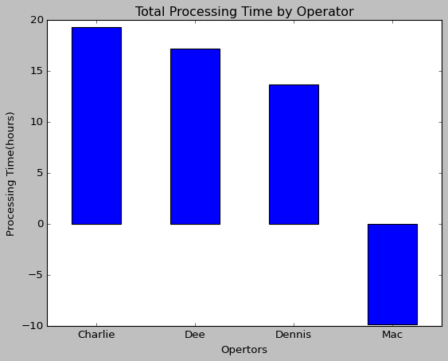

```python
plt.figure(figsize=(10,6))
operator_analysis.plot(kind='bar',x='Operator',y='Processing Time',legend=False)
plt.title('Total Processing Time by Operator')
plt.ylabel('Processing Time(hours)')
plt.xlabel('Opertors')
plt.xticks(rotation=360)
plt.show()
```

### Line Plot

Over time we see that productivity rises from august 29 and it dips in August 31 (it was a saturday), it peaked september 2 which was a monday, there was a drop september 3, this needs to be analyzed futrher.

```python
plt.style.use('bmh')
```

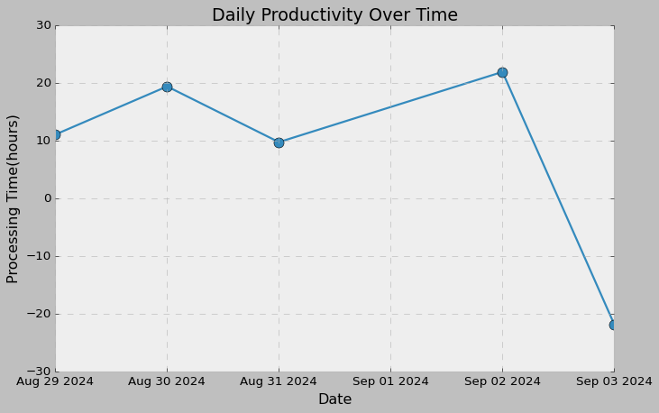

```python
plt.figure(figsize=(10,6))
plt.plot(daily_productivity['Date'],daily_productivity['Processing Time'], marker='o', ms=10)
plt.title('Daily Productivity Over Time')
plt.ylabel('Processing Time(hours)')
plt.xlabel('Date')
plt.xticks(rotation=360)
plt.show()
```

### Bar chart

Orange 600ml has the highest processing time, Root Beer 600ml edges Cola 600ml by a bit, Diet Cola 600ml and Lemon Lime 600ml have the same average processing time, while Cola 2L has the lowest average processing time.

```python
plt.style.use('Solarize_Light2')
```

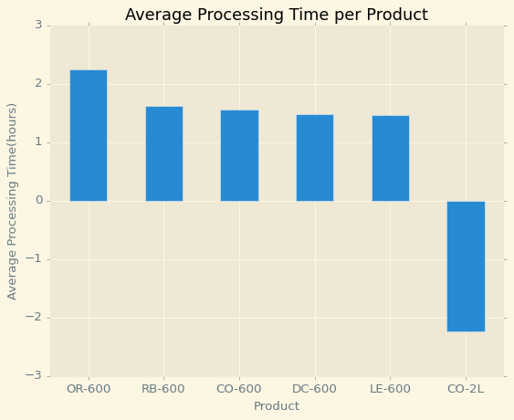

```python
plt.figure(figsize=(10,6))
pt_per_product.plot(kind='bar',x='Product',y='Processing Time',legend=False)
plt.title('Average Processing Time per Product')
plt.xlabel('Product')
plt.ylabel('Average Processing Time(hours)')
plt.xticks(rotation=360)
plt.show()
```

### Stacked Bar Chart

```python
grouped_data = df.groupby(['Product','Operator'])['Processing Time'].sum().unstack()
print(grouped_data)
```

```
Operator   Charlie       Dee    Dennis        Mac
Product
CO-2L     8.083333       NaN  2.533333 -21.833333
CO-600    7.566667  9.116667  6.550000        NaN
DC-600         NaN  1.333333       NaN   4.583333
LE-600    3.650000       NaN       NaN   5.166667
OR-600         NaN       NaN       NaN   2.250000
RB-600         NaN  6.716667  4.583333        NaN
```

```python
plt.style.use('fivethirtyeight')
```

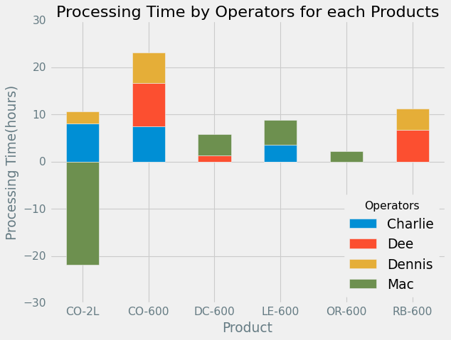

```python
plt.figure(figsize=(10,6))
grouped_data.plot(kind='bar',stacked=True)
plt.title('Processing Time by Operators for each Products')
plt.xlabel('Product')
plt.ylabel('Processing Time(hours)')
plt.legend(title='Operators',loc='lower right')
plt.xticks(rotation=360)
plt.show()
```

### Pie Chart

- The pie chart shows the percentage from each operator, Charlie has the highest percentage.
- I could not add Mac because, the pie chart doesn't read negative values.

```python
operator_total = df.groupby('Operator')['Processing Time'].sum().head(3)
print(operator_total)
```

```
Operator
Charlie    19.300000
Dee        17.166667
Dennis     13.666667
Name: Processing Time, dtype: float64
```

```python
plt.style.use('fivethirtyeight')
```

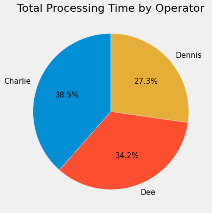

```python
plt.figure(figsize=(10,6))
operator_total.plot(kind='pie',autopct='%1.1f%%',startangle=90)
plt.title('Total Processing Time by Operator')
plt.ylabel('')
plt.show()
```

### Heatmap

The heat map conveys the same insight as the stacked bar chart, with more specificity with the amount of hours spent by each operator.

```python
heatmap_data = df.pivot_table(values='Processing Time',index='Operator',columns='Product',aggfunc='sum')
print(heatmap_data)
```

```
Product       CO-2L    CO-600    DC-600    LE-600  OR-600    RB-600
Operator
Charlie    8.083333  7.566667       NaN  3.650000     NaN       NaN
Dee             NaN  9.116667  1.333333       NaN     NaN  6.716667
Dennis     2.533333  6.550000       NaN       NaN     NaN  4.583333
Mac      -21.833333       NaN  4.583333  5.166667    2.25       NaN
```

```python
plt.style.use('seaborn-v0_8-notebook')
```

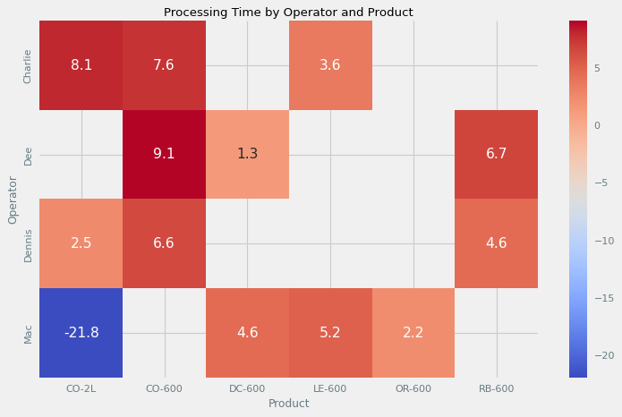

```python
plt.figure(figsize=(10,6))
sns.heatmap(heatmap_data,annot=True,cmap='coolwarm',fmt='.1f')
plt.title('Processing Time by Operator and Product')
plt.xlabel('Product')
plt.ylabel('Operator')
plt.show()
```

### Scatter Plot

```python
plt.style.use('_classic_test_patch')
```

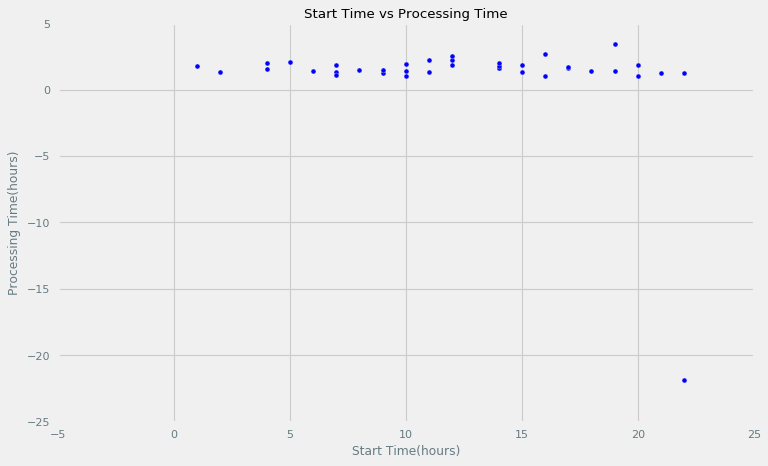

```python
plt.figure(figsize=(10,6))
plt.scatter(df['Start Time'].dt.hour, df['Processing Time'])
plt.title('Start Time vs Processing Time')
plt.xlabel('Start Time(hours)')
plt.ylabel('Processing Time(hours)')
plt.show()
```